# 란 12.3 — 121분의 역사를 다시 살게 하는 영화

Culture Voyager #4 | 블랙코미디와 다큐 사이, 그날 밤의 두 가지 기록법

Author

Nakcho Choi

Published

May 5, 2026

## 새벽 4시, 잠이 오지 않는 이유

미국행 비행기에서 **“어쩔 수가 없다”**를 봤다. 어제 출발 전에는 조조로 **“란 12.3”**을 봤다. 하루 사이에 두 편을 연달아 본 것이다.

그런데 이상한 일이 벌어졌다. 두 영화가 머릿속에서 분리되지 않는다.

하나는 블랙코미디다. 이명세 감독이 2024년 12월 3일 밤을 재구성한 극영화. 다른 하나는 박찬욱의 조용한 폭력 — 해고당한 남자가 양복을 입고 텅 빈 거리를 걷는 이야기.

장르가 다르고, 소재가 다르고, 톤이 완전히 다른데 — **이 두 영화는 같은 질문을 하고 있다.**

> “어쩔 수 없다”는 무슨 뜻인가?

## 그날 밤의 핵심 장면: 시민 283명의 스마트폰

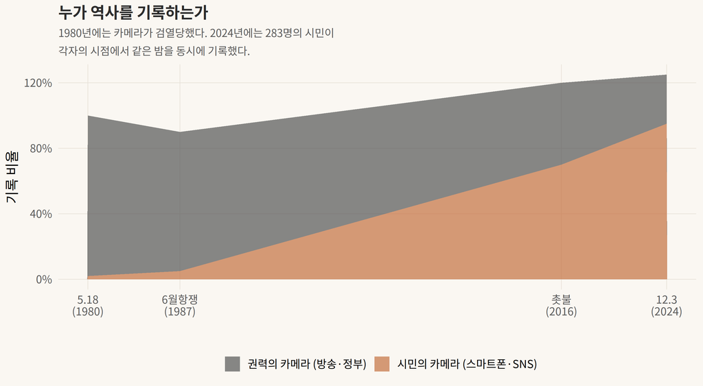

역사의 기록 수단이 바뀌었다 — 카메라는 더 이상 권력의 전유물이 아니다

란 12.3의 압도적인 장면은 국회 안이 아니다. **시민들이 스마트폰을 들어올리는 순간이다.**

“지금 국회 앞이에요. 헬기 소리 들려요.” “본회의장 들어간대요.” “우리 아이에게 부끄럽지 않은 밤이기를.”

카카오톡, 유튜브 라이브, 인스타그램 스토리. 2024년 12월 3일 밤, 역사는 방송국이 아니라 **시민 283명의 스마트폰**으로 기록됐다. 이명세는 이 시점들을 CCTV 화면처럼 교차편집한다.

여기서 기시감이 든다. 1980년 5월, 광주에서는 카메라가 없었다. 있었어도 필름이 압수됐다. 기록이 없으니 “그런 일은 없었다”가 가능했다.

44년 뒤, **기록을 막는 것이 불가능해졌다.** 그리고 이명세는 그 불가능성 자체를 영화의 형식으로 만들었다.

## 두 감독의 설계도 — 같은 밤, 다른 렌즈

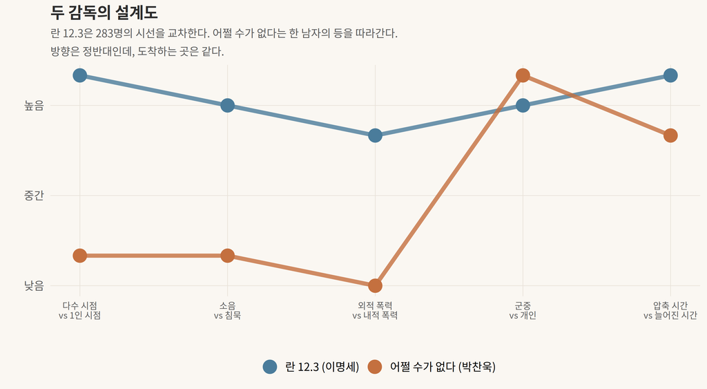

이명세는 밖에서 안을 본다. 박찬욱은 안에서 밖을 본다.

이명세와 박찬욱. 한국 영화의 두 거장이 같은 시대를 전혀 다른 방식으로 해부한다.

**란 12.3**은 밖에서 안을 본다. 283명의 시민, CCTV, 뉴스 화면, 카카오톡 캡처. 시점이 폭발적으로 분산된다. 관객은 그날 밤 거기 있었던 사람이 된다. 소리가 많다. 헬기, 구호, 사이렌, 알림음. 이명세 특유의 과잉이 오히려 다큐보다 더 생생하다.

**어쩔 수가 없다**는 안에서 밖을 본다. 만수 한 사람. 양복 하나. 텅 빈 거리. 소리가 없다. 박찬욱의 절제가 오히려 블랙코미디보다 더 잔인하다.

**그런데 둘 다 같은 것을 찍고 있다.** 시스템이 개인을 버리는 순간.

란 12.3에서 시스템은 국가다. 계엄을 선포하고 국회를 봉쇄하는 권력. 어쩔 수가 없다에서 시스템은 회사다. 30년 일한 사람에게 “수고하셨습니다” 한 마디로 존재를 지우는 조직.

**국가든 회사든, 시스템은 같은 문법으로 작동한다.** “어쩔 수 없었다.”

## 블랙코미디라는 무기

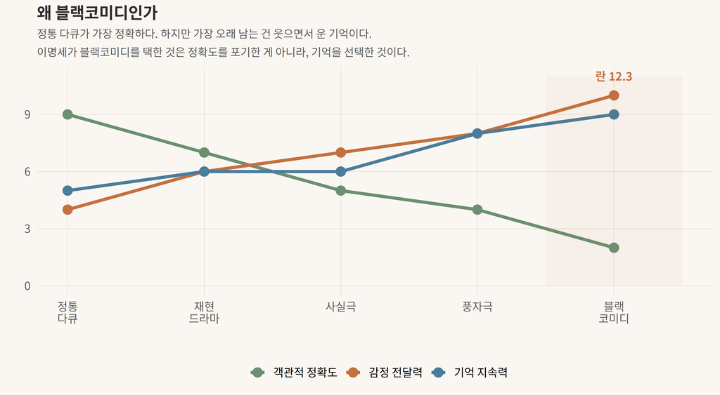

웃기면 웃길수록 진짜가 된다 — 블랙코미디의 역설

이명세는 왜 12.3을 블랙코미디로 찍었을까?

다큐멘터리가 있다. 뉴스 영상이 있다. 국회 청문회 녹화가 있다. 사실 자체는 이미 충분히 기록됐다. 그런데 이명세는 여기에 웃음을 얹었다.

계엄군 장교가 국회 앞에서 우왕좌왕하는 장면. 명령 체계가 꼬여서 서로 다른 지시를 받은 부대가 맞닥뜨리는 장면. 부조리극처럼 연출한다.

**왜 웃기게 만들었나?**

분노는 휘발된다. 슬픔도 잊힌다. 하지만 **웃으면서 동시에 소름이 돋은 기억**은 몸에 새겨진다. 이명세는 이걸 안다. 감독 생활 40년의 직관이다.

영화를 보는 121분 동안 관객은 웃다가 멈춘다. 멈추는 그 순간이 진짜다. “이걸 웃어도 되나?” 하는 찰나에 — 이것이 실제로 일어난 일이라는 사실이 얼굴을 때린다.

## “어쩔 수 없다”의 두 가지 용법

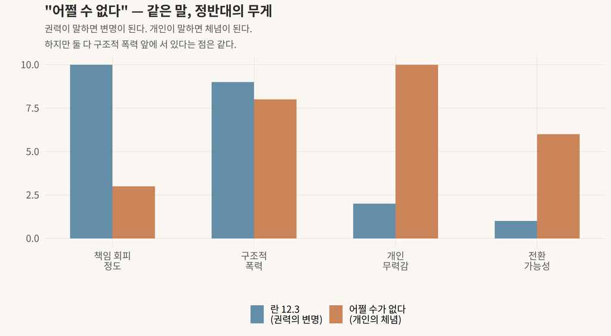

같은 말, 정반대의 의미

12.3 당일, 관계자들의 입에서 반복된 말이 있다. **“어쩔 수 없었다.”**

“명령이었으니까 어쩔 수 없었다.” “상황이 그러니까 어쩔 수 없었다.” “나 혼자 막을 수 없으니까 어쩔 수 없었다.”

란 12.3에서 이 말은 **변명**이다. 책임 회피의 문법. 아이히만의 진부함. “나는 명령에 따랐을 뿐이다.”

그런데 같은 해, 박찬욱의 영화 제목도 “어쩔 수가 없다”다.

여기서는 의미가 뒤집힌다. 만수는 아무것도 나쁜 짓을 하지 않았다. 30년을 성실하게 일했다. 그런데 해고됐다. “어쩔 수가 없다”는 만수의 입에서 나오면 **체념**이 된다. 혹은 — 분노를 삼킨 뒤에 남는 찌꺼기.

**같은 네 글자가 권력의 입에서 나오면 면죄부가 되고, 개인의 입에서 나오면 사형선고가 된다.**

이것이 한국어의 잔인함이고, 이 두 영화를 나란히 놓았을 때 비로소 보이는 것이다.

## 다큐를 거부하는 다큐

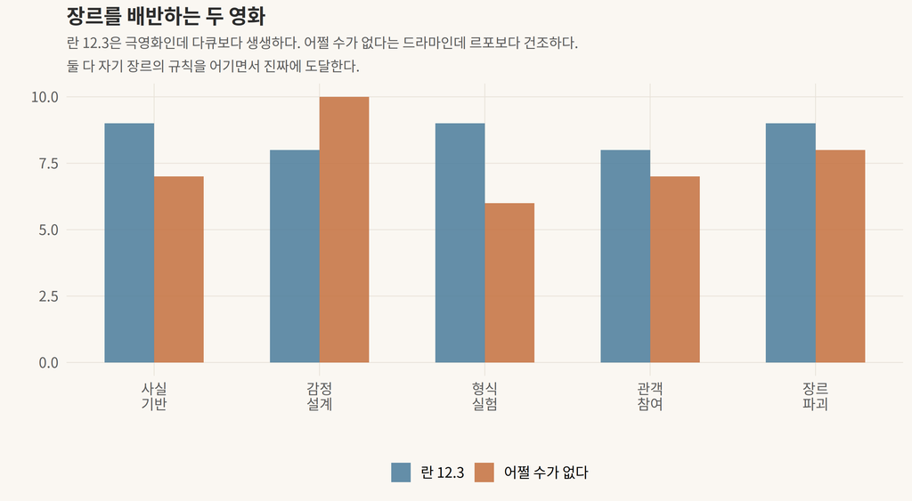

장르의 경계에서 — 두 영화 모두 자기 장르를 배반한다

이명세는 인터뷰에서 말했다. “다큐를 거부하는 다큐를 만들고 싶었다.”

사실 기반이다. 실제 CCTV 영상, 실제 카카오톡 대화, 실제 뉴스 속보를 사용한다. 하지만 연출은 극영화다. 배우가 연기하고, 편집은 오케스트라처럼 리듬을 탄다. 블랙코미디의 타이밍으로 실제 사건을 재구성한다.

결과는 기묘하다. **극영화인데 다큐보다 더 “진짜” 같다.**

왜? 다큐는 사실을 보여주지만, 사실이 주는 감정까지 설계하지는 못한다. 이명세는 감정을 설계했다. 관객이 웃고, 멈추고, 소름 돋고, 분노하는 타이밍을 121분 안에 배치했다.

박찬욱의 “어쩔 수가 없다”도 마찬가지다. 극영화인데 르포르타주보다 더 건조하다. 해고, 구직, 좌절의 루틴이 반복된다. 감정을 절제하면 할수록 관객의 감정이 더 강하게 치민다.

**두 감독 모두 장르의 규칙을 어겼고, 그래서 진짜에 도달했다.**

## 155분과 121분 — 시간의 설계

란 12.3의 러닝타임은 121분이다. 공교롭게도 2024년 12월 3일 밤, 계엄 선포에서 국회 해제 결의까지 걸린 시간과 거의 같다.

이것이 우연일 리 없다. 이명세는 **관객에게 그날 밤의 시간을 살게 한 것이다.** 영화가 시작되면 관객은 2024년 12월 3일 밤 10시에 서 있고, 영화가 끝나면 새벽이다. 실시간 체험.

반면 박찬욱의 어쩔 수가 없다는 155분이다. 만수의 시간은 느리게 흐른다. 해고 이후의 시간이란 그런 것이다 — 할 일이 없으면 하루가 일주일 같다. 155분이 지루하게 느껴진다면, 그것이 정확히 박찬욱이 의도한 것이다.

**121분은 역사의 속도. 155분은 개인의 속도.** 두 시간의 무게는 전혀 다르다.

## 잠이 오지 않는 진짜 이유

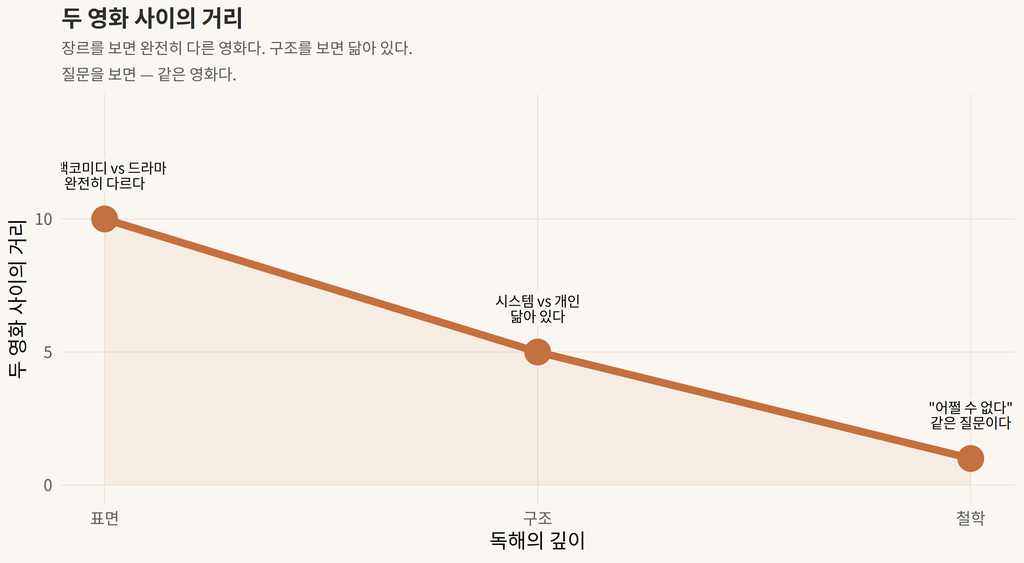

두 영화가 머릿속에서 분리되지 않는 이유

새벽 4시. 비행기 안. 잠이 오지 않는다.

란 12.3을 보고 나서는 분노했다. 어쩔 수가 없다를 보고 나서는 서글펐다. 그런데 지금, 두 감정이 섞여서 이상한 것이 됐다.

**분노와 서글픔이 섞이면 뭐가 되나?** — 각성.

란 12.3은 “시스템이 어떻게 개인을 짓밟는가”를 보여준다. 국가라는 시스템이 한밤중에 군대를 보내 국회를 봉쇄하는 장면. 어쩔 수가 없다는 “시스템이 어떻게 개인을 버리는가”를 보여준다. 회사라는 시스템이 30년 된 사원에게 종이 한 장을 건네는 장면.

**봉쇄와 해고. 방법은 다르지만 문법은 같다.** “조직을 위해 어쩔 수 없었다.”

그날 밤 국회 앞에 선 시민 283명은 — 어쩔 수 없지 않았다. 새벽에 잠옷 위에 패딩을 걸치고 나와서 스마트폰을 들었다. “어쩔 수 없다”를 거부한 것이다.

만수는? 만수는 아직 거부하지 못했다. 양복을 입고 텅 빈 거리를 걷고 있다. 하지만 영화의 마지막에서 — 아주 천천히 — 양복 재킷의 단추를 푼다.

**단추를 푸는 것이 만수의 스마트폰이다.** 시스템의 유니폼을 벗는 첫 번째 행위.

## 판결 — 하루에 두 편을 봐야 하는 이유

두 영화를 따로 봐도 좋다. 하지만 **연달아 보면 전혀 다른 것이 보인다.**

란 12.3만 보면 — “저들이 나쁘다”에서 끝난다. 분노하고, 공유하고, 잊는다.

어쩔 수가 없다만 보면 — “나도 만수다”에서 끝난다. 서글퍼하고, 고개를 끄덕이고, 다음 날 출근한다.

**둘을 같이 보면?** “저들”과 “나”가 같은 시스템 안에 있다는 걸 깨닫는다. 국가가 시민을 버리는 것과 회사가 직원을 버리는 것은 — 규모만 다를 뿐 구조가 같다.

그리고 283명의 시민이 증명했다. **“어쩔 수 없다”는 거짓말이다.** 어쩔 수 있다. 스마트폰 하나로, 단추 하나로.

> 란 12.3은 “어쩔 수 없다”가 거짓말임을 증명한다. 어쩔 수가 없다는 “어쩔 수 없다”를 넘어서는 첫 걸음을 보여준다. 한 편은 거부를, 한 편은 시작을.

*이전 호: 어쩔 수가 없다 — 노동이라는 종교의 최후 신자*

*Culture Voyager Vol.04 | 2026.05.05*